# Technical Report

Evan Pugh

12/1/2019

### Abstract

This project seeks to analyze what factors effect the death rate behind specific illnesses. The illnesses we have chosen to analyze are HIV-AIDs, Influenza, Tuberculosis, Neoplasms (tumors) and Pneumonia.

### Introduction

Our data comes from the OECD, or Organisation for Economic Co-operation and Development. The OECD is a group of nations who share data that they have gathered about themselves in order to seek solutions to shared problems, identify good policies and coordinate efforts between member countries. Here is a map highlighting all 36 nations in the OECD:

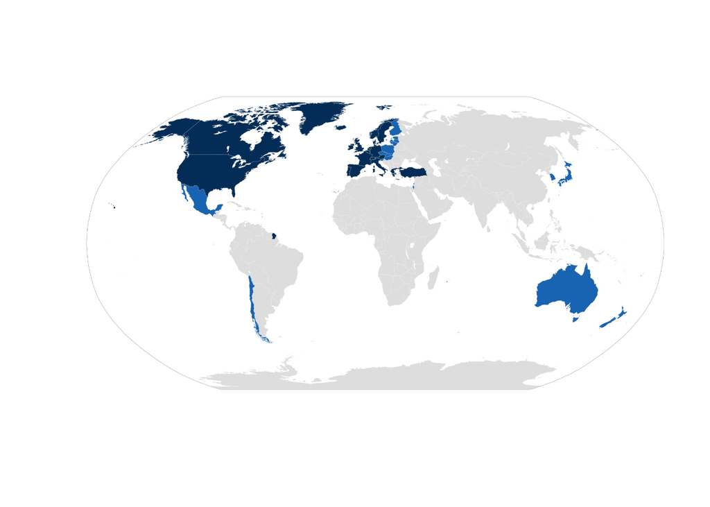

```r
plot(OECD, axes = FALSE)
```

As you can probably tell from looking at the map, most of the countries on this map are countries that have a high income per capita and a high Human Development Index. In addition to these 36 countries, our data set also contains data on Brazil, Colombia, Costa Rica, Russia and South Africa. For this analysize we have choosen to measure data from 1990 to 2016

#### Exploratory Data Analysis

```r
death_rates <- read_csv("data/death_rates.csv")
employment <- read_csv("data/employment.csv")
GDPs <- read_csv("data/GDPs.csv")
insurance <- read_csv("data/insurance.csv")
populations <- read_csv("data/populations.csv")
PublicExp <- read_csv("data/PublicExp.csv")
GovtExp <- read_csv("data/GovtExp.csv")
employment = employment[employment$Measure=="Density per 1 000 population (head counts)",]
employment = cbind(employment[6],employment[8:9])

death_rates = cbind(death_rates[2],death_rates[6],death_rates[8:9])
GDPs = cbind(GDPs[6],GDPs[8:9])
populations = cbind(populations[6],populations[8:9])
insurance = cbind(insurance[6],insurance[8:9])
GovtExp = cbind(GovtExp[10],GovtExp[12],GovtExp[19])
PublicExp = cbind(PublicExp[10],PublicExp[12],PublicExp[19])
```

Let’s start by plotting the number of deaths per 100,000 people for each of our five causes of death by year. Each of the 41 countries has been given a unique color and shape combination in order to indentify it and track it.

Units:

All disease variables are reported as deaths per 100,000 people

Employment represents number of people whose job involves human health activities, residential care and social work activities per 1,000 people.

Population is the population of the country measured in thousands of people.

GDP is measured in US dollars per capita

Coverage represents the percentage of the population who are covered by public or private insurance.

GovtExp is the amount of money the government spends per person on healthcare costs with a constant PPP (also includes compulsory healthcare costs)

PublicExp is the amount of money individuals spend on healthcare per capita with a constant PPP.

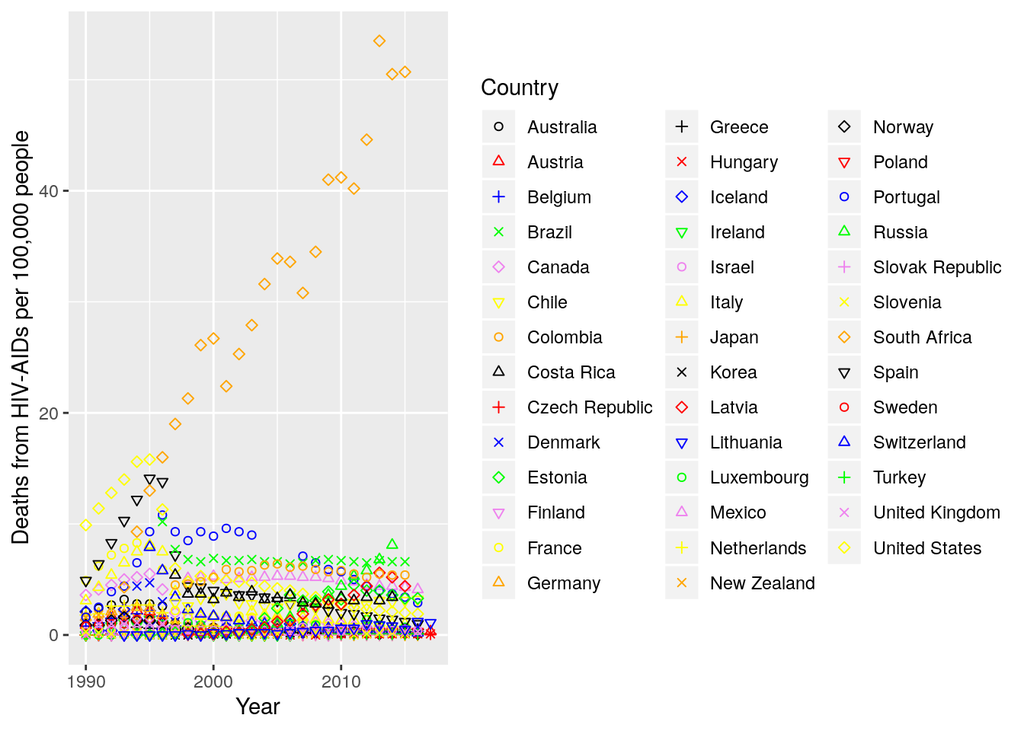

```r
colors = rep(c("black","red","blue","green","violet","yellow","orange"),6)
shapes = rep(c(1,2,3,4,5,6),7)

death_rates=death_rates[death_rates$Year>1989,]
HIV = death_rates[death_rates$Variable == "HIV-AIDS",]
Flu = death_rates[death_rates$Variable == "Influenza",]
Tub = death_rates[death_rates$Variable == "Tuberculosis",]
Neo = death_rates[death_rates$Variable == "Neoplasms",]
Pne= death_rates[death_rates$Variable == "Pneumonia",]

ggplot(HIV, aes(x=Year, y=Value,color=Country,shape=Country)) + geom_point()+
  scale_shape_manual(values=shapes[0:41])+
  scale_color_manual(values=colors[0:41]) + ylab("Deaths from HIV-AIDs per 100,000 people")
```

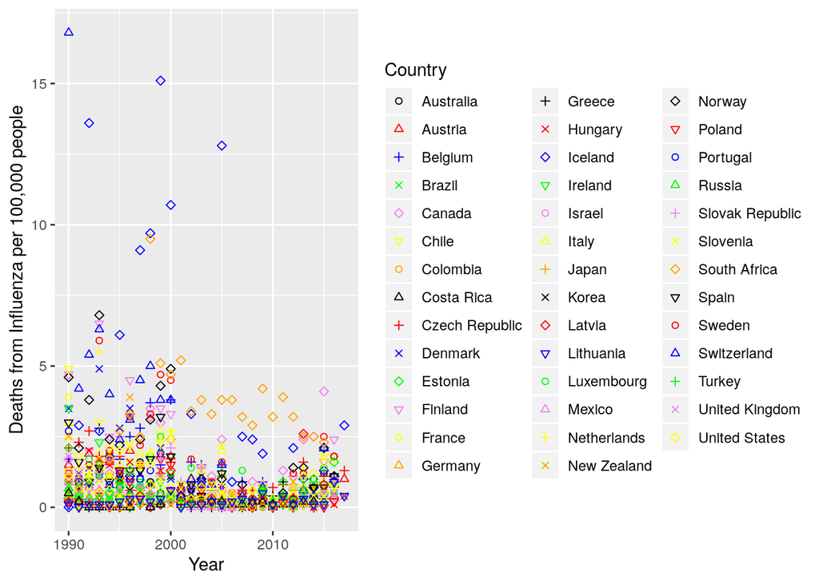

```r
ggplot(Flu, aes(x=Year, y=Value,color=Country,shape=Country)) + geom_point()+
  scale_shape_manual(values=shapes[0:41])+
  scale_color_manual(values=colors[0:41]) + ylab("Deaths from Influenza per 100,000 people")
```

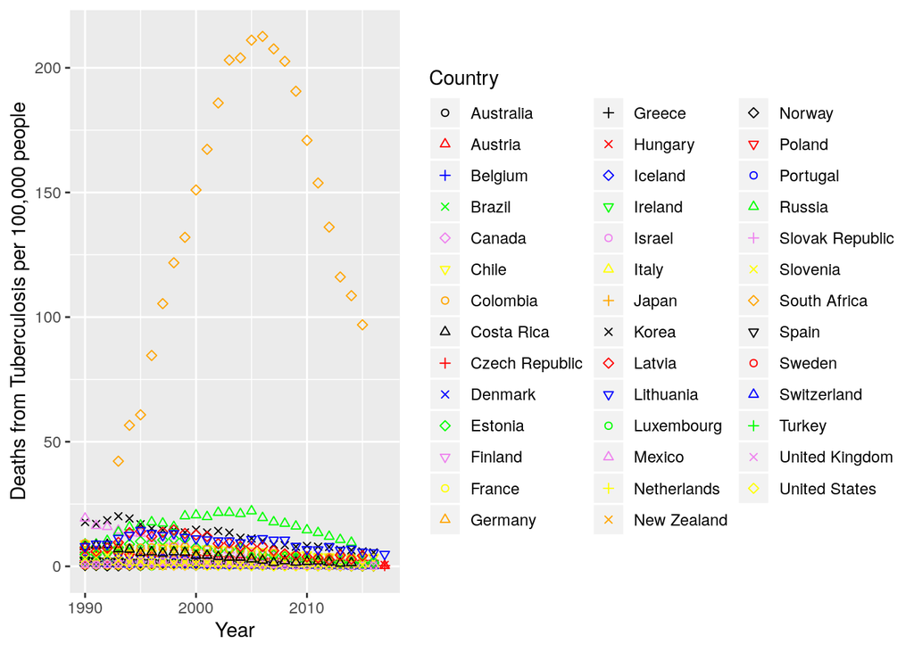

```r
ggplot(Tub, aes(x=Year, y=Value,color=Country,shape=Country)) + geom_point()+
  scale_shape_manual(values=shapes[0:41])+
  scale_color_manual(values=colors[0:41]) + ylab("Deaths from Tuberculosis per 100,000 people")
```

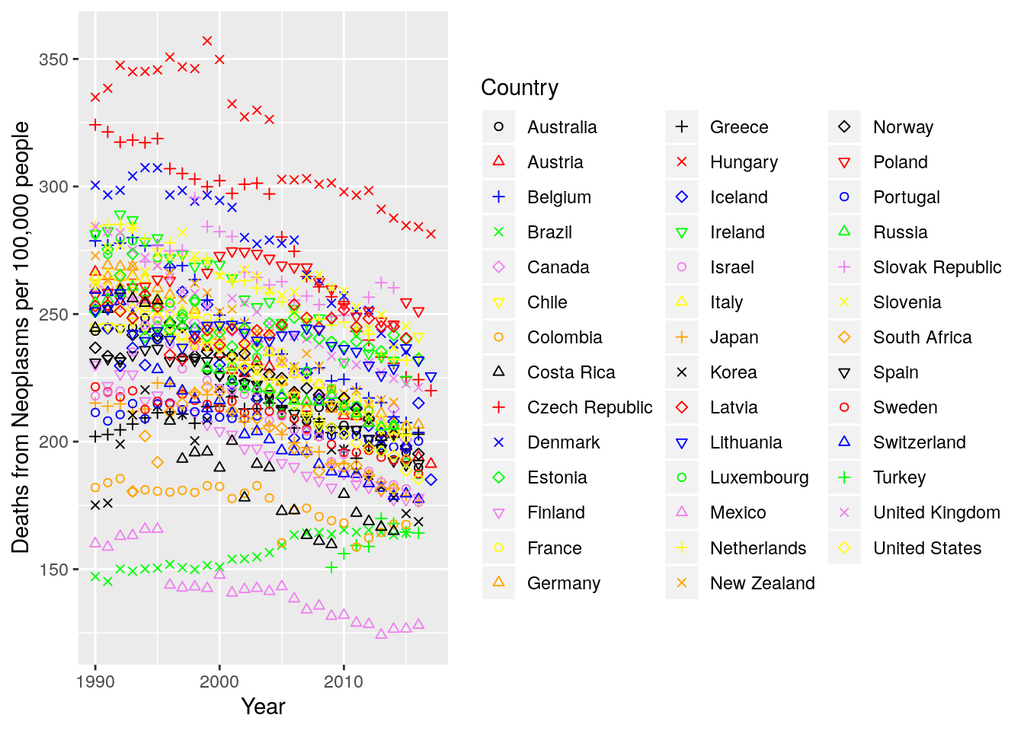

```r
ggplot(Neo, aes(x=Year, y=Value,color=Country,shape=Country)) + geom_point()+
  scale_shape_manual(values=shapes[0:41])+
  scale_color_manual(values=colors[0:41]) + ylab("Deaths from Neoplasms per 100,000 people")
```

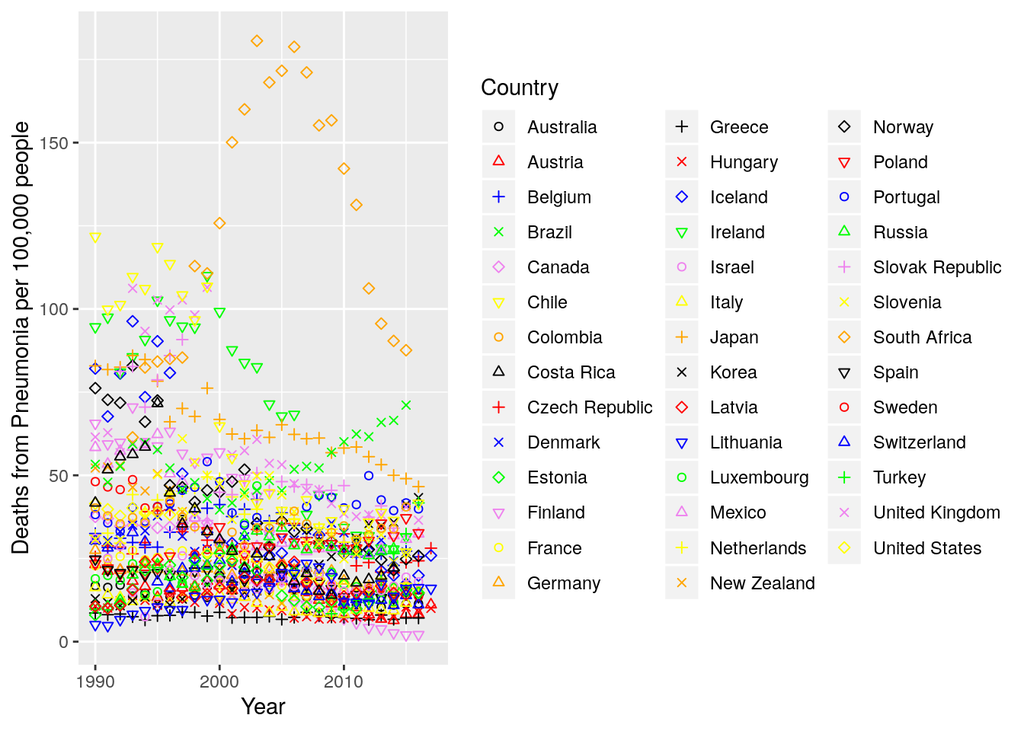

```r
ggplot(Pne, aes(x=Year, y=Value,color=Country,shape=Country)) + geom_point()+
  scale_shape_manual(values=shapes[0:41])+
  scale_color_manual(values=colors[0:41]) + ylab("Deaths from Pneumonia per 100,000 people")
```

```r
final = death_rates[,2:3]
final = unique(final)
final = left_join(final,HIV[,2:4], by = c("Country"="Country","Year"="Year"))
names(final) <- c("Country","Year", "HIV-Aids")

final = left_join(final,Flu[,2:4], by = c("Country"="Country","Year"="Year"))
names(final) <- c("Country","Year", "HIV-Aids","Influenza")

final = left_join(final,Tub[,2:4], by = c("Country"="Country","Year"="Year"))
names(final) <- c("Country","Year", "HIV-Aids","Influenza","Tuberculosis")

final = left_join(final,Neo[,2:4], by = c("Country"="Country","Year"="Year"))
names(final) <- c("Country","Year", "HIV-Aids","Influenza","Tuberculosis","Neoplasms")

final = left_join(final,Pne[,2:4], by = c("Country"="Country","Year"="Year"))
names(final) <- c("Country", "Year", "HIV-Aids", "Influenza", "Tuberculosis", "Neoplasms", "Pneumonia")

final = left_join(final,employment, by = c("Country"="Country","Year"="Year"))
names(final) <- c("Country", "Year", "HIV-Aids", "Influenza", "Tuberculosis", "Neoplasms", "Pneumonia","Employment")

final = left_join(final,populations, by = c("Country"="Country","Year"="Year"))
names(final) <- c("Country", "Year", "HIV-Aids", "Influenza", "Tuberculosis", "Neoplasms", "Pneumonia","Employment","Population")

final = left_join(final,GDPs, by = c("Country"="Country","Year"="Year"))
names(final) <- c("Country", "Year", "HIV", "Influenza", "Tuberculosis", "Neoplasms", "Pneumonia","Employment","Population", "GDP")

final = left_join(final,insurance, by = c("Country"="Country","Year"="Year"))
names(final) <- c("Country", "Year", "HIV", "Influenza", "Tuberculosis", "Neoplasms", "Pneumonia","Employment","Population", "GDP","Coverage")

final = left_join(final,GovtExp, by = c("Country"="Country","Year"="Year"))
names(final) <- c("Country", "Year", "HIV", "Influenza", "Tuberculosis", "Neoplasms", "Pneumonia","Employment","Population", "GDP","Coverage","GovtExp")

final = left_join(final,PublicExp, by = c("Country"="Country","Year"="Year"))
names(final) <- c("Country", "Year", "HIV", "Influenza", "Tuberculosis", "Neoplasms", "Pneumonia","Employment","Population", "GDP","Coverage","GovtExp","PublicExp")

final = unique(final)
```

#### Exercise 4

```r
mHIV = lm(final$HIV ~ final$Year + final$Employment + final$Coverage + final$PublicExp)
summary(mHIV)
```

```
##
## Call:
## lm(formula = final$HIV ~ final$Year + final$Employment + final$Coverage +
##     final$PublicExp)
##
## Residuals:
##     Min      1Q  Median      3Q     Max
## -2.1179 -0.9280 -0.3223  0.2509 11.7992
##
## Coefficients:
##                    Estimate Std. Error t value Pr(>|t|)
## (Intercept)       1.706e+02  2.112e+01   8.076 3.78e-15 ***
## final$Year       -7.976e-02  1.046e-02  -7.626 9.74e-14 ***
## final$Employment -1.656e-02  3.379e-03  -4.900 1.24e-06 ***
## final$Coverage   -9.206e-02  1.329e-02  -6.927 1.13e-11 ***
## final$PublicExp   5.526e-04  1.279e-04   4.322 1.81e-05 ***
## ---
## Signif. codes:  0 '***' 0.001 '**' 0.01 '*' 0.05 '.' 0.1 ' ' 1
##
## Residual standard error: 1.69 on 589 degrees of freedom
##   (468 observations deleted due to missingness)
## Multiple R-squared:  0.2264, Adjusted R-squared:  0.2211
## F-statistic: 43.08 on 4 and 589 DF,  p-value: < 2.2e-16
```

```r
mFlu = lm(final$Influenza ~ final$Year + final$Employment + final$Population + final$GDP)
summary(mFlu)
```

```
##
## Call:
## lm(formula = final$Influenza ~ final$Year + final$Employment +
##     final$Population + final$GDP)
##
## Residuals:
##     Min      1Q  Median      3Q     Max
## -1.5437 -0.5452 -0.1726  0.3164  4.7838
##
## Coefficients:
##                    Estimate Std. Error t value Pr(>|t|)
## (Intercept)       9.545e+01  1.005e+01   9.500  < 2e-16 ***
## final$Year       -4.750e-02  5.014e-03  -9.474  < 2e-16 ***
## final$Employment  1.964e-02  2.099e-03   9.356  < 2e-16 ***
## final$Population -1.155e-06  5.853e-07  -1.974  0.04874 *
## final$GDP        -7.876e-06  2.477e-06  -3.179  0.00154 **
## ---
## Signif. codes:  0 '***' 0.001 '**' 0.01 '*' 0.05 '.' 0.1 ' ' 1
##
## Residual standard error: 0.829 on 717 degrees of freedom
##   (340 observations deleted due to missingness)
## Multiple R-squared:  0.2647, Adjusted R-squared:  0.2606
## F-statistic: 64.54 on 4 and 717 DF,  p-value: < 2.2e-16
```

```r
mTub = lm(final$Tuberculosis ~  final$Population + final$GDP + final$GovtExp+final$Coverage*final$Population+final$Coverage*final$Employment)
summary(mTub)
```

```
##
## Call:
## lm(formula = final$Tuberculosis ~ final$Population + final$GDP +
##     final$GovtExp + final$Coverage * final$Population + final$Coverage *
##     final$Employment)
##
## Residuals:
##     Min      1Q  Median      3Q     Max
## -3.9423 -0.6376 -0.1382  0.2307  6.4653
##
## Coefficients:
##                                   Estimate Std. Error t value Pr(>|t|)
## (Intercept)                      2.053e+01  1.866e+00  11.006  < 2e-16 ***
## final$Population                -1.301e-04  1.913e-05  -6.799 2.54e-11 ***
## final$GDP                        4.781e-06  5.333e-06   0.896   0.3704
## final$GovtExp                   -7.411e-04  1.043e-04  -7.103 3.46e-12 ***
## final$Coverage                  -1.846e-01  1.950e-02  -9.469  < 2e-16 ***
## final$Employment                 1.250e-01  7.278e-02   1.718   0.0864 .
## final$Population:final$Coverage  1.403e-06  2.000e-07   7.017 6.14e-12 ***
## final$Coverage:final$Employment -1.218e-03  7.258e-04  -1.679   0.0938 .
## ---
## Signif. codes:  0 '***' 0.001 '**' 0.01 '*' 0.05 '.' 0.1 ' ' 1
##
## Residual standard error: 1.144 on 601 degrees of freedom
##   (453 observations deleted due to missingness)
## Multiple R-squared:  0.3871, Adjusted R-squared:   0.38
## F-statistic: 54.23 on 7 and 601 DF,  p-value: < 2.2e-16
```

```r
mPne = lm(final$Pneumonia ~ final$Year + final$Employment + final$Population + final$GDP + final$Coverage + final$GovtExp + final$PublicExp )
summary(mPne)
```

```
##
## Call:
## lm(formula = final$Pneumonia ~ final$Year + final$Employment +
##     final$Population + final$GDP + final$Coverage + final$GovtExp +
##     final$PublicExp)
##
## Residuals:
##    Min     1Q Median     3Q    Max
## -28.07 -11.68  -2.37   9.65  73.84
##
## Coefficients:
##                    Estimate Std. Error t value Pr(>|t|)
## (Intercept)       1.645e+03  2.359e+02   6.972 8.19e-12 ***
## final$Year       -8.180e-01  1.160e-01  -7.054 4.78e-12 ***
## final$Employment  1.943e-01  5.574e-02   3.485 0.000528 ***
## final$Population  1.502e-04  1.761e-05   8.529  < 2e-16 ***
## final$GDP         3.821e-04  8.269e-05   4.621 4.66e-06 ***
## final$Coverage    2.886e-01  1.438e-01   2.007 0.045204 *
## final$GovtExp    -9.250e-03  1.504e-03  -6.149 1.41e-09 ***
## final$PublicExp  -1.391e-02  1.585e-03  -8.777  < 2e-16 ***
## ---
## Signif. codes:  0 '***' 0.001 '**' 0.01 '*' 0.05 '.' 0.1 ' ' 1
##
## Residual standard error: 16.26 on 605 degrees of freedom
##   (449 observations deleted due to missingness)
## Multiple R-squared:  0.2719, Adjusted R-squared:  0.2634
## F-statistic: 32.27 on 7 and 605 DF,  p-value: < 2.2e-16
```

```r
mNeo = lm(final$Neoplasms~ final$Year + final$Employment + final$Population + final$GDP + final$Coverage + final$GovtExp)
summary(mNeo)
```

```
##
## Call:
## lm(formula = final$Neoplasms ~ final$Year + final$Employment +
##     final$Population + final$GDP + final$Coverage + final$GovtExp)
##
## Residuals:
##     Min      1Q  Median      3Q     Max
## -70.793 -21.433  -3.073  20.136  97.956
##
## Coefficients:
##                    Estimate Std. Error t value Pr(>|t|)
## (Intercept)       3.345e+03  4.207e+02   7.951 9.11e-15 ***
## final$Year       -1.608e+00  2.070e-01  -7.770 3.38e-14 ***
## final$Employment  1.665e-01  9.937e-02   1.676   0.0943 .
## final$Population -1.484e-04  2.816e-05  -5.269 1.91e-07 ***
## final$GDP        -1.317e-03  1.405e-04  -9.375  < 2e-16 ***
## final$Coverage    1.200e+00  2.561e-01   4.686 3.44e-06 ***
## final$GovtExp     1.475e-02  2.693e-03   5.478 6.33e-08 ***
## ---
## Signif. codes:  0 '***' 0.001 '**' 0.01 '*' 0.05 '.' 0.1 ' ' 1
##
## Residual standard error: 29.13 on 606 degrees of freedom
##   (449 observations deleted due to missingness)
## Multiple R-squared:  0.3724, Adjusted R-squared:  0.3662
## F-statistic: 59.93 on 6 and 606 DF,  p-value: < 2.2e-16
```

So in summary:

Our model for HIV had an R-squared of 0.2264 and found that the Year, Employment, Coverage, and Public Expenditure were statistically significant variables.

Our model for Pneumonia had an R-squared of 0.2719 and found that all of our variables were statistically significant variables.

Our model for Neoplasms had an R-squared of 0.3724 and found that the Year, Population, GDP Coverage, and Government Expenditure were statistically significant variables.

Now, undoubtally there are some variables effecting this data that are not in this data set. There are a tens of thousands of variables that could effect these death rates, everything from the climate to the form of government. To try and account for many of these, let’s add Country to the list of variables as a proxy for the variables that we have not accounted for but are mostly static for a given country.

```r
m2HIV = lm(final$HIV ~ final$Year + final$Population + final$GDP + final$Country)
summary(m2HIV)
```

```
##
## Call:
## lm(formula = final$HIV ~ final$Year + final$Population + final$GDP +
##     final$Country)
##
## Residuals:
##      Min       1Q   Median       3Q      Max
## -26.2280  -0.5337  -0.1007   0.2311  23.3598
##
## Coefficients:
##                                Estimate Std. Error t value Pr(>|t|)
## (Intercept)                  -1.008e+02  3.649e+01  -2.763 0.005845 **
## final$Year                    5.268e-02  1.843e-02   2.858 0.004362 **
## final$Population             -1.002e-04  1.944e-05  -5.156 3.09e-07 ***
## final$GDP                    -4.431e-05  1.138e-05  -3.894 0.000106 ***
## final$CountryAustria         -1.494e+00  7.112e-01  -2.100 0.035965 *
## final$CountryBelgium         -1.414e+00  7.038e-01  -2.008 0.044895 *
## final$CountryBrazil           2.091e+01  3.273e+00   6.389 2.66e-10 ***
## final$CountryCanada           1.995e+00  7.199e-01   2.772 0.005687 **
## final$CountryChile            5.129e-02  8.236e-01   0.062 0.950356
## final$CountryColombia         5.261e+00  9.418e-01   5.586 3.07e-08 ***
## final$CountryCosta Rica      -6.988e-01  9.153e-01  -0.763 0.445418
## final$CountryCzech Republic  -3.101e+00  7.760e-01  -3.996 6.95e-05 ***
## final$CountryDenmark         -1.152e+00  7.744e-01  -1.487 0.137243
## final$CountryEstonia         -2.236e+00  8.715e-01  -2.566 0.010459 *
## final$CountryFinland         -2.495e+00  7.419e-01  -3.364 0.000801 ***
## final$CountryFrance           5.689e+00  1.064e+00   5.345 1.14e-07 ***
## final$CountryGermany          5.875e+00  1.362e+00   4.313 1.79e-05 ***
## final$CountryGreece          -2.554e+00  7.354e-01  -3.473 0.000540 ***
## final$CountryHungary         -3.223e+00  7.840e-01  -4.111 4.30e-05 ***
## final$CountryIceland         -2.238e+00  8.542e-01  -2.620 0.008929 **
## final$CountryIreland         -2.273e+00  7.502e-01  -3.030 0.002516 **
## final$CountryIsrael          -2.535e+00  7.450e-01  -3.403 0.000695 ***
## final$CountryItaly            5.187e+00  1.005e+00   5.161 3.02e-07 ***
## final$CountryJapan            9.654e+00  2.181e+00   4.427 1.07e-05 ***
## final$CountryKorea            9.522e-01  9.164e-01   1.039 0.299010
## final$CountryLatvia          -2.120e+00  9.227e-01  -2.298 0.021802 *
## final$CountryLithuania       -3.735e+00  8.706e-01  -4.290 1.98e-05 ***
## final$CountryLuxembourg      -9.345e-01  8.725e-01  -1.071 0.284382
## final$CountryMexico           1.142e+01  1.895e+00   6.023 2.48e-09 ***
## final$CountryNetherlands     -4.856e-01  6.815e-01  -0.713 0.476337
## final$CountryNew Zealand     -2.525e+00  7.725e-01  -3.268 0.001123 **
## final$CountryNorway          -1.101e+00  7.759e-01  -1.419 0.156271
## final$CountryPoland          -3.711e-01  8.937e-01  -0.415 0.678089
## final$CountryPortugal         3.350e+00  7.641e-01   4.384 1.30e-05 ***
## final$CountryRussia           1.261e+01  2.515e+00   5.015 6.38e-07 ***
## final$CountrySlovak Republic -3.742e+00  8.741e-01  -4.280 2.06e-05 ***
## final$CountrySlovenia        -3.647e+00  8.288e-01  -4.401 1.21e-05 ***
## final$CountrySouth Africa     3.053e+01  9.427e-01  32.392  < 2e-16 ***
## final$CountrySpain            5.320e+00  8.183e-01   6.501 1.31e-10 ***
## final$CountrySweden          -1.526e+00  7.107e-01  -2.148 0.031988 *
## final$CountrySwitzerland      1.831e-01  7.901e-01   0.232 0.816795
## final$CountryTurkey           2.969e+00  1.480e+00   2.006 0.045099 *
## final$CountryUnited Kingdom   3.351e+00  1.039e+00   3.224 0.001307 **
## final$CountryUnited States    3.214e+01  5.273e+00   6.096 1.60e-09 ***
## ---
## Signif. codes:  0 '***' 0.001 '**' 0.01 '*' 0.05 '.' 0.1 ' ' 1
##
## Residual standard error: 2.464 on 913 degrees of freedom
##   (105 observations deleted due to missingness)
## Multiple R-squared:  0.7999, Adjusted R-squared:  0.7905
## F-statistic: 84.89 on 43 and 913 DF,  p-value: < 2.2e-16
```

```r
m2Flu = lm(final$Influenza ~ final$Year + final$Population + final$GDP + final$GovtExp + final$PublicExp + final$Country)
summary(m2Flu)
```

```
##
## Call:
## lm(formula = final$Influenza ~ final$Year + final$Population +
##     final$GDP + final$GovtExp + final$PublicExp + final$Country)
##
## Residuals:
##     Min      1Q  Median      3Q     Max
## -4.9088 -0.4225 -0.1036  0.2481 10.6182
##
## Coefficients:
##                                Estimate Std. Error t value Pr(>|t|)
## (Intercept)                   4.131e+01  2.037e+01   2.028 0.042859 *
## final$Year                   -2.001e-02  1.031e-02  -1.941 0.052536 .
## final$Population              2.783e-05  9.698e-06   2.869 0.004213 **
## final$GDP                    -2.370e-05  5.976e-06  -3.966 7.91e-05 ***
## final$GovtExp                -7.886e-05  1.441e-04  -0.547 0.584448
## final$PublicExp              -1.489e-04  2.264e-04  -0.658 0.510807
## final$CountryAustria          5.206e-01  3.462e-01   1.504 0.132972
## final$CountryBelgium          1.054e+00  3.377e-01   3.122 0.001854 **
## final$CountryBrazil          -5.875e+00  1.766e+00  -3.327 0.000916 ***
## final$CountryCanada           4.428e-01  3.082e-01   1.437 0.151154
## final$CountryChile           -8.842e-01  4.072e-01  -2.171 0.030185 *
## final$CountryColombia        -2.102e+00  5.541e-01  -3.793 0.000159 ***
## final$CountryCosta Rica      -8.441e-01  4.499e-01  -1.876 0.060937 .
## final$CountryCzech Republic  -4.603e-02  3.492e-01  -0.132 0.895153
## final$CountryDenmark          1.141e+00  3.542e-01   3.221 0.001327 **
## final$CountryEstonia         -2.838e-01  4.414e-01  -0.643 0.520519
## final$CountryFinland          1.400e+00  3.254e-01   4.303 1.88e-05 ***
## final$CountryFrance          -7.921e-01  4.726e-01  -1.676 0.094053 .
## final$CountryGermany         -2.014e+00  6.120e-01  -3.292 0.001036 **
## final$CountryGreece          -7.086e-01  3.137e-01  -2.259 0.024152 *
## final$CountryHungary         -5.825e-01  3.488e-01  -1.670 0.095283 .
## final$CountryIceland          4.217e+00  3.666e-01  11.502  < 2e-16 ***
## final$CountryIreland          4.448e-01  3.299e-01   1.348 0.177980
## final$CountryIsrael          -3.897e-01  3.518e-01  -1.108 0.268249
## final$CountryItaly           -8.265e-01  4.642e-01  -1.780 0.075368 .
## final$CountryJapan           -3.102e+00  1.076e+00  -2.884 0.004026 **
## final$CountryKorea           -1.498e+00  4.697e-01  -3.190 0.001473 **
## final$CountryLatvia          -2.822e-01  4.498e-01  -0.627 0.530572
## final$CountryLithuania       -5.513e-01  4.142e-01  -1.331 0.183573
```

[output cut: 9 more lines]

```
## final$CountrySlovenia        -2.742e-01  4.090e-01  -0.670 0.502823
## final$CountrySouth Africa     1.202e+00  5.645e-01   2.129 0.033569 *
## final$CountrySpain           -7.618e-01  3.857e-01  -1.975 0.048575 *
## final$CountrySweden           1.440e+00  3.299e-01   4.364 1.43e-05 ***
## final$CountrySwitzerland      2.072e+00  4.522e-01   4.582 5.28e-06 ***
## final$CountryTurkey          -2.433e+00  8.134e-01  -2.991 0.002863 **
## final$CountryUnited Kingdom  -1.533e+00  5.173e-01  -2.963 0.003134 **
## final$CountryUnited States   -7.002e+00  2.496e+00  -2.806 0.005133 **
## ---
## Signif. codes:  0 '***' 0.001 '**' 0.01 '*' 0.05 '.' 0.1 ' ' 1
##
## Residual standard error: 1.045 on 865 degrees of freedom
##   (151 observations deleted due to missingness)
## Multiple R-squared:   0.45,  Adjusted R-squared:  0.4214
## F-statistic: 15.73 on 45 and 865 DF,  p-value: < 2.2e-16
```

```r
m2Tub = lm(final$Tuberculosis ~ final$Year + final$Employment + final$Population + final$GDP + final$Coverage + final$GovtExp + final$PublicExp + final$Country)
summary(m2Tub)
```

```
##
## Call:
## lm(formula = final$Tuberculosis ~ final$Year + final$Employment +
##     final$Population + final$GDP + final$Coverage + final$GovtExp +
##     final$PublicExp + final$Country)
##
## Residuals:
##     Min      1Q  Median      3Q     Max
## -1.4762 -0.2163 -0.0231  0.1620  3.6306
##
## Coefficients:
##                                Estimate Std. Error t value Pr(>|t|)
## (Intercept)                   2.146e+02  1.419e+01  15.127  < 2e-16 ***
## final$Year                   -1.063e-01  7.234e-03 -14.700  < 2e-16 ***
## final$Employment             -5.375e-03  7.134e-03  -0.753 0.451528
## final$Population              6.796e-06  1.041e-05   0.653 0.514153
## final$GDP                     1.046e-05  3.519e-06   2.974 0.003069 **
## final$Coverage               -2.782e-02  7.497e-03  -3.711 0.000226 ***
## final$GovtExp                 4.614e-04  1.023e-04   4.510 7.86e-06 ***
## final$PublicExp               3.397e-04  1.396e-04   2.433 0.015274 *
## final$CountryAustria          1.907e-01  2.476e-01   0.770 0.441434
## final$CountryBelgium          3.346e-01  2.090e-01   1.601 0.109857
## final$CountryCanada          -5.384e-02  1.902e-01  -0.283 0.777282
## final$CountryChile            4.951e+00  3.188e-01  15.529  < 2e-16 ***
## final$CountryCzech Republic   1.347e+00  2.524e-01   5.336 1.37e-07 ***
## final$CountryDenmark          1.996e-01  3.167e-01   0.630 0.528730
## final$CountryEstonia          4.351e+00  3.265e-01  13.326  < 2e-16 ***
## final$CountryFinland          1.401e+00  2.157e-01   6.495 1.81e-10 ***
## final$CountryFrance           2.496e-01  4.325e-01   0.577 0.564110
## final$CountryGermany         -5.030e-01  6.189e-01  -0.813 0.416645
## final$CountryGreece           8.527e-01  2.817e-01   3.027 0.002584 **
## final$CountryHungary          3.393e+00  2.495e-01  13.596  < 2e-16 ***
## final$CountryIceland          1.143e+00  3.153e-01   3.626 0.000313 ***
## final$CountryIreland          7.747e-01  2.434e-01   3.183 0.001538 **
## final$CountryIsrael           1.438e+00  2.134e-01   6.741 3.88e-11 ***
## final$CountryItaly            1.867e-01  4.102e-01   0.455 0.649091
## final$CountryJapan            1.652e+00  1.101e+00   1.500 0.134173
## final$CountryKorea            8.037e+00  3.918e-01  20.513  < 2e-16 ***
## final$CountryLithuania        7.735e+00  3.326e-01  23.254  < 2e-16 ***
## final$CountryMexico           3.989e+00  1.096e+00   3.640 0.000298 ***
## final$CountryNetherlands      2.100e-02  1.972e-01   0.106 0.915249
## final$CountryNew Zealand      9.387e-01  4.003e-01   2.345 0.019373 *
## final$CountryNorway          -3.959e-02  3.410e-01  -0.116 0.907605
## final$CountryPoland           2.667e+00  3.296e-01   8.093 3.56e-15 ***
## final$CountryPortugal         2.714e+00  2.347e-01  11.563  < 2e-16 ***
## final$CountrySlovak Republic  1.628e+00  2.895e-01   5.624 2.93e-08 ***
## final$CountrySlovenia         1.558e+00  3.196e-01   4.875 1.41e-06 ***
## final$CountrySpain            8.751e-01  3.354e-01   2.609 0.009327 **
## final$CountrySweden           2.568e-01  2.557e-01   1.004 0.315737
## final$CountrySwitzerland     -5.455e-01  2.632e-01  -2.073 0.038652 *
## final$CountryTurkey           2.517e+00  6.623e-01   3.800 0.000160 ***
## final$CountryUnited Kingdom   4.490e-01  4.552e-01   0.986 0.324397
## final$CountryUnited States   -3.756e+00  2.950e+00  -1.273 0.203429
## ---
## Signif. codes:  0 '***' 0.001 '**' 0.01 '*' 0.05 '.' 0.1 ' ' 1
##
## Residual standard error: 0.4763 on 568 degrees of freedom
##   (453 observations deleted due to missingness)
## Multiple R-squared:  0.8995, Adjusted R-squared:  0.8925
## F-statistic: 127.1 on 40 and 568 DF,  p-value: < 2.2e-16
```

```r
m2Pne = lm(final$Pneumonia ~ final$Year + final$Employment + final$Population + final$GDP + final$Coverage + final$GovtExp + final$PublicExp + final$Country)
summary(m2Pne)
```

```
##
## Call:
## lm(formula = final$Pneumonia ~ final$Year + final$Employment +
##     final$Population + final$GDP + final$Coverage + final$GovtExp +
##     final$PublicExp + final$Country)
##
## Residuals:
##     Min      1Q  Median      3Q     Max
## -23.509  -4.080   0.047   3.880  38.946
##
## Coefficients:
##                                Estimate Std. Error t value Pr(>|t|)
## (Intercept)                  -7.813e+01  2.517e+02  -0.310  0.75635
## final$Year                    7.130e-02  1.283e-01   0.556  0.57862
## final$Employment             -1.415e-01  1.264e-01  -1.120  0.26338
## final$Population              6.014e-04  1.852e-04   3.248  0.00123 **
## final$GDP                     5.279e-06  6.212e-05   0.085  0.93231
## final$Coverage               -1.726e-01  1.334e-01  -1.294  0.19610
## final$GovtExp                -1.284e-02  1.815e-03  -7.074 4.42e-12 ***
## final$PublicExp              -1.461e-02  2.479e-03  -5.894 6.44e-09 ***
## final$CountryAustria          1.762e+01  4.402e+00   4.003 7.08e-05 ***
## final$CountryBelgium          2.941e+01  3.715e+00   7.915 1.29e-14 ***
## final$CountryCanada           6.126e+00  3.384e+00   1.810  0.07078 .
## final$CountryChile           -1.289e+00  5.659e+00  -0.228  0.81994
## final$CountryCzech Republic   2.466e+00  4.484e+00   0.550  0.58263
## final$CountryDenmark          3.695e+01  5.620e+00   6.574 1.11e-10 ***
## final$CountryEstonia         -1.456e+01  5.800e+00  -2.510  0.01234 *
## final$CountryFinland          2.885e+01  3.836e+00   7.520 2.13e-13 ***
## final$CountryFrance          -1.382e+01  7.692e+00  -1.797  0.07282 .
## final$CountryGermany         -1.614e+01  1.101e+01  -1.467  0.14305
## final$CountryGreece          -1.539e+01  5.003e+00  -3.076  0.00220 **
## final$CountryHungary         -2.041e+01  4.433e+00  -4.604 5.10e-06 ***
## final$CountryIceland          2.818e+01  5.166e+00   5.455 7.29e-08 ***
## final$CountryIreland          6.095e+01  4.326e+00  14.089  < 2e-16 ***
## final$CountryIsrael          -3.778e+00  3.792e+00  -0.996  0.31953
## final$CountryItaly           -3.059e+01  7.294e+00  -4.194 3.18e-05 ***
## final$CountryJapan           -1.757e+01  1.958e+01  -0.897  0.36991
## final$CountryKorea           -1.367e+01  6.964e+00  -1.963  0.05015 .
## final$CountryLithuania       -1.152e+01  5.909e+00  -1.950  0.05164 .
## final$CountryMexico          -7.792e+01  1.949e+01  -3.998 7.22e-05 ***
## final$CountryNetherlands      3.753e+01  3.499e+00  10.728  < 2e-16 ***
## final$CountryNew Zealand      1.491e+01  7.120e+00   2.095  0.03665 *
## final$CountryNorway           5.610e+01  6.055e+00   9.264  < 2e-16 ***
## final$CountryPoland          -1.891e+01  5.855e+00  -3.230  0.00131 **
## final$CountryPortugal         2.121e+01  4.172e+00   5.085 4.99e-07 ***
## final$CountrySlovak Republic  1.759e+01  5.143e+00   3.420  0.00067 ***
## final$CountrySlovenia         1.841e+01  5.678e+00   3.242  0.00126 **
## final$CountrySpain           -2.444e+01  5.963e+00  -4.099 4.76e-05 ***
## final$CountrySweden           2.482e+01  4.541e+00   5.466 6.88e-08 ***
## final$CountrySwitzerland      4.020e+01  4.676e+00   8.598  < 2e-16 ***
## final$CountryTurkey          -6.055e+01  1.177e+01  -5.144 3.70e-07 ***
## final$CountryUnited Kingdom   1.458e+01  8.095e+00   1.801  0.07226 .
## final$CountryUnited States   -1.026e+02  5.247e+01  -1.955  0.05111 .
## ---
## Signif. codes:  0 '***' 0.001 '**' 0.01 '*' 0.05 '.' 0.1 ' ' 1
##
## Residual standard error: 8.473 on 572 degrees of freedom
##   (449 observations deleted due to missingness)
## Multiple R-squared:  0.813,  Adjusted R-squared:  0.7999
## F-statistic: 62.17 on 40 and 572 DF,  p-value: < 2.2e-16
```

```r
m2Neo = lm(final$Neoplasms~ final$Year + final$Employment + final$Population + final$GDP + final$Coverage + final$GovtExp + final$PublicExp + final$Country)
summary(m2Neo)
```

```
##
## Call:
## lm(formula = final$Neoplasms ~ final$Year + final$Employment +
##     final$Population + final$GDP + final$Coverage + final$GovtExp +
##     final$PublicExp + final$Country)
##
## Residuals:
##     Min      1Q  Median      3Q     Max
## -25.114  -3.417  -0.263   3.294  36.276
##
## Coefficients:
##                                Estimate Std. Error t value Pr(>|t|)
## (Intercept)                   5.103e+03  2.103e+02  24.262  < 2e-16 ***
## final$Year                   -2.454e+00  1.072e-01 -22.888  < 2e-16 ***
## final$Employment              1.797e-01  1.056e-01   1.701  0.08947 .
## final$Population             -2.350e-04  1.547e-04  -1.519  0.12930
## final$GDP                    -2.947e-05  5.191e-05  -0.568  0.57052
## final$Coverage                2.891e-01  1.114e-01   2.594  0.00973 **
## final$GovtExp                 4.627e-04  1.517e-03   0.305  0.76039
## final$PublicExp              -6.986e-05  2.071e-03  -0.034  0.97311
## final$CountryAustria          6.071e+00  3.678e+00   1.650  0.09940 .
## final$CountryBelgium          2.042e+01  3.105e+00   6.576 1.09e-10 ***
## final$CountryCanada           1.740e+01  2.828e+00   6.152 1.44e-09 ***
## final$CountryChile            2.255e+01  4.729e+00   4.768 2.37e-06 ***
## final$CountryCzech Republic   5.942e+01  3.747e+00  15.857  < 2e-16 ***
## final$CountryDenmark          4.595e+01  4.697e+00   9.783  < 2e-16 ***
## final$CountryEstonia          3.820e+01  4.846e+00   7.883 1.63e-14 ***
## final$CountryFinland         -2.707e+01  3.206e+00  -8.446 2.50e-16 ***
## final$CountryFrance           2.356e+01  6.427e+00   3.665  0.00027 ***
## final$CountryGermany          2.481e+01  9.196e+00   2.697  0.00719 **
## final$CountryGreece          -5.659e+00  4.181e+00  -1.354  0.17635
## final$CountryHungary          1.040e+02  3.705e+00  28.061  < 2e-16 ***
## final$CountryIceland          3.281e+00  4.317e+00   0.760  0.44756
## final$CountryIreland          3.434e+01  3.615e+00   9.499  < 2e-16 ***
## final$CountryIsrael          -7.821e+00  3.169e+00  -2.468  0.01387 *
## final$CountryItaly            2.797e+01  6.095e+00   4.589 5.49e-06 ***
## final$CountryJapan            1.201e+01  1.636e+01   0.734  0.46338
## final$CountryKorea           -1.629e+00  5.819e+00  -0.280  0.77958
## final$CountryLithuania        3.823e+01  4.938e+00   7.741 4.49e-14 ***
## final$CountryMexico          -3.533e+01  1.628e+01  -2.169  0.03047 *
## final$CountryNetherlands      3.475e+01  2.924e+00  11.887  < 2e-16 ***
## final$CountryNew Zealand      1.653e+01  5.950e+00   2.778  0.00566 **
## final$CountryNorway          -6.946e+00  5.060e+00  -1.373  0.17035
## final$CountryPoland           6.487e+01  4.893e+00  13.258  < 2e-16 ***
## final$CountryPortugal        -7.410e+00  3.486e+00  -2.125  0.03398 *
## final$CountrySlovak Republic  5.223e+01  4.297e+00  12.154  < 2e-16 ***
## final$CountrySlovenia         4.778e+01  4.745e+00  10.069  < 2e-16 ***
## final$CountrySpain            9.822e+00  4.983e+00   1.971  0.04919 *
## final$CountrySweden          -1.837e+01  3.795e+00  -4.840 1.67e-06 ***
## final$CountrySwitzerland     -2.043e+01  3.907e+00  -5.229 2.40e-07 ***
## final$CountryTurkey          -1.511e+01  9.836e+00  -1.536  0.12509
## final$CountryUnited Kingdom   3.804e+01  6.764e+00   5.624 2.92e-08 ***
## final$CountryUnited States    7.015e+01  4.384e+01   1.600  0.11013
## ---
## Signif. codes:  0 '***' 0.001 '**' 0.01 '*' 0.05 '.' 0.1 ' ' 1
##
## Residual standard error: 7.081 on 572 degrees of freedom
##   (449 observations deleted due to missingness)
## Multiple R-squared:  0.965,  Adjusted R-squared:  0.9626
## F-statistic: 394.3 on 40 and 572 DF,  p-value: < 2.2e-16
```

This model for Pneumonia has an R-squared of 0.8126, an increase of 0.5407 from our previous model.

So HIV, Tuberculosis, Pneumonia and Neoplasms are all heavily effected by variables that we do not have that are baked in to each of our countries, while Influenza is only mildly effected by these variables.

To get a visual idea of how good this model is, let’s look at this graph showing the actual HIV rate in Australia from 1990-2016 vs our predicted HIV rate in Australia from 1990-2016.

```r
Aus = final[final$Country=="Australia",]
prediction1 = predict.lm(mHIV, Aus)
```

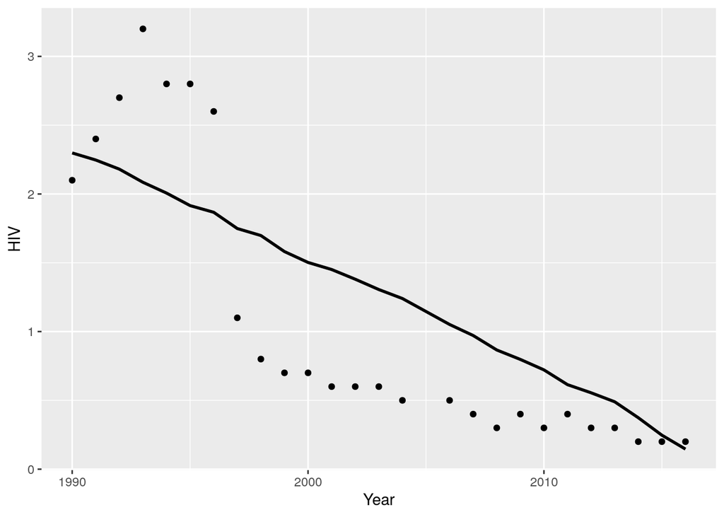

```r
prediction1 = prediction1[1:26]

ggplot(Aus, aes(x = Year, y = HIV)) +
     geom_point() +
  geom_line(aes(y = prediction1), size = 1)
```

Finding optimal lambdas for glm

```r
set.seed(42)


testH = na.omit(final[,-4:-7])


x1 <- testH %>% select(Year, Employment, Population, GDP, Coverage, GovtExp, PublicExp) %>% data.matrix()
y1 <- testH$HIV
lambdas <- 10^seq(3, -10, by = -.1)
cv_fit <- cv.glmnet(x1, y1, alpha = .8, lambda = lambdas)

cv_fit$lambda.min
```

```
## [1] 0.007943282
```

```r
temp = final[,-3]
test2 = na.omit(temp[,-4:-6])


x2 <- test2 %>% select(Year, Employment, Population, GDP, Coverage, GovtExp, PublicExp) %>% data.matrix()
y2 <- test2$Influenza
lambdas <- 10^seq(1, -8, by = -.1)
cv_fit2 <- cv.glmnet(x2, y2, alpha = .8, lambda = lambdas)
cv_fit2$lambda.min
```

```
## [1] 0.001995262
```

```r
temp = final[,-3:-4]
test3 = na.omit(temp[,-4:-5])

x3 <- test3 %>% select(Year, Employment, Population, GDP, Coverage, GovtExp, PublicExp) %>% data.matrix()
y3 <- test3$Tuberculosis

cv_fit3 <- cv.glmnet(x3, y3, alpha = .8, lambda = lambdas)
cv_fit3$lambda.min
```

```
## [1] 0.0005011872
```

```r
temp = final[,-3:-5]
test4 = na.omit(temp[,-4])

x4 <- test4 %>% select(Year, Employment, Population, GDP, Coverage, GovtExp, PublicExp) %>% data.matrix()
y4 <- test4$Neoplasms

cv_fit4 <- cv.glmnet(x4, y4, alpha = .8, lambda = lambdas)
cv_fit4$lambda.min
```

```
## [1] 1e-08
```

```r
temp = final[,-3:-6]
test5 = na.omit(temp)

x5 <- test5 %>% select(Year, Employment, Population, GDP, Coverage, GovtExp, PublicExp) %>% data.matrix()
y5 <- test5$Pneumonia

cv_fit5 <- cv.glmnet(x5, y5, alpha = .8, lambda = lambdas)
cv_fit5$lambda.min
```

```
## [1] 0.006309573
```

```r
glmHIV <- glmnet(x1, y1, alpha = .8, lambda = 0.0158)

summary(glmHIV$beta)
```

```
## 7 x 1 sparse Matrix of class "dgCMatrix", with 6 entries
##   i j             x
## 1 1 1 -7.365966e-02
## 2 2 1 -1.318974e-02
## 3 3 1  8.864938e-07
## 4 4 1 -4.703265e-06
## 5 5 1 -8.635925e-02
## 6 7 1  5.137765e-04
```

```r
coef(mHIV)
```

```
##      (Intercept)       final$Year final$Employment   final$Coverage
##     1.705753e+02    -7.976073e-02    -1.655621e-02    -9.205960e-02
##  final$PublicExp
##     5.526049e-04
```

Messing around with training and test data, test data for lm is wonky

```r
set.seed(42)
train = sample(1:nrow(x1), nrow(x1)/2)


x1_train = x1[train,]
y1_train = y1[train]
x1_test = x1[-train,]
y1_test = y1[-train]



fit1 <- glmnet(x1_train, y1_train, alpha = .8, lambda = 0.0158)

preds <- predict(fit1,newx = x1_test)
actual <- y1_test
rss <- sum((preds - actual) ^ 2)
tss <- sum((actual - mean(actual)) ^ 2)
rsq1 <- 1 - rss/tss
rsq1
```

```
## [1] 0.2029935
```

```r
x2_train = x2[train,]
y2_train = y2[train]
x2_test = x2[-train,]
y2_test = y2[-train]

fit2 <- glmnet(x2_train, y2_train, alpha = .8, lambda = 0.0158)

preds <- predict(fit2,newx = x2_test)
actual <- y2_test
rss <- sum((preds - actual) ^ 2)
tss <- sum((actual - mean(actual)) ^ 2)
rsq2 <- 1 - rss/tss
rsq2
```

```
## [1] 0.2524919
```

```r
x3_train = x3[train,]
y3_train = y3[train]
x3_test = x3[-train,]
y3_test = y3[-train]

fit3 <- glmnet(x3_train, y3_train, alpha = .8, lambda = 0.0158)

preds <- predict(fit3,newx = x3_test)
actual <- y3_test
rss <- sum((preds - actual) ^ 2)
tss <- sum((actual - mean(actual)) ^ 2)
rsq3 <- 1 - rss/tss
rsq3
```

```
## [1] 0.2621682
```

```r
x4_train = x4[train,]
y4_train = y4[train]
x4_test = x4[-train,]
y4_test = y4[-train]

fit4 <- glmnet(x4_train, y4_train, alpha = .8, lambda = 0.0158)

preds <- predict(fit4,newx = x4_test)
actual <- y4_test
rss <- sum((preds - actual) ^ 2)
tss <- sum((actual - mean(actual)) ^ 2)
rsq <- 1 - rss/tss
rsq
```

```
## [1] 0.3249221
```

```r
x5_train = x5[train,]
y5_train = y5[train]
x5_test = x5[-train,]
y5_test = y5[-train]

fit5 <- glmnet(x5_train, y5_train, alpha = .8, lambda = 0.0158)

preds <- predict(fit5,newx = x5_test)
actual <- y5_test
rss <- sum((preds - actual) ^ 2)
tss <- sum((actual - mean(actual)) ^ 2)
rsq5 <- 1 - rss/tss
rsq5
```

```
## [1] 0.276382
```

Messing around with PCA

```r
set.seed(42)

temp = na.omit(final)

dim(temp)
```

```
## [1] 581  13
```

```r
train = sample(1:nrow(temp), nrow(temp)/2)
temp.pca <- prcomp(na.omit(cbind(temp[,2],temp[8:13])))
summary(temp.pca)
```

```
## Importance of components:
##                              PC1       PC2       PC3       PC4   PC5   PC6
## Standard deviation     5.706e+04 1.775e+04 510.20959 428.18164 13.22 6.001
## Proportion of Variance 9.116e-01 8.827e-02   0.00007   0.00005  0.00 0.000
## Cumulative Proportion  9.116e-01 9.999e-01   0.99995   1.00000  1.00 1.000
##                          PC7
## Standard deviation     4.491
## Proportion of Variance 0.000
## Cumulative Proportion  1.000
```

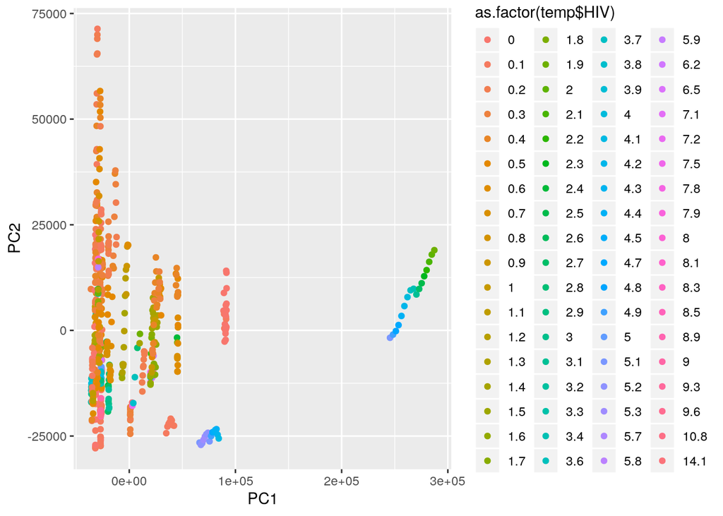

```r
temp$PC1 <- temp.pca$x[,1]
temp$PC2 <- temp.pca$x[,2]
temp$PC3 <- temp.pca$x[,3]
temp$PC4 <- temp.pca$x[,4]

ggplot(temp, aes(x = PC1, y = PC2, colour = as.factor(temp$HIV))) + geom_point()
```

```r
coef(fit1)
```

```
## 8 x 1 sparse Matrix of class "dgCMatrix"
##                        s0
## (Intercept)  1.247315e+02
## Year        -5.720237e-02
## Employment  -8.578151e-03
## Population   9.454608e-07
## GDP         -9.537581e-06
## Coverage    -8.570010e-02
## GovtExp     -1.122960e-04
## PublicExp    6.297057e-04
```

```r
summary(mHIV)
```

```
##
## Call:
## lm(formula = final$HIV ~ final$Year + final$Employment + final$Coverage +
##     final$PublicExp)
##
## Residuals:
##     Min      1Q  Median      3Q     Max
## -2.1179 -0.9280 -0.3223  0.2509 11.7992
##
## Coefficients:
##                    Estimate Std. Error t value Pr(>|t|)
## (Intercept)       1.706e+02  2.112e+01   8.076 3.78e-15 ***
## final$Year       -7.976e-02  1.046e-02  -7.626 9.74e-14 ***
## final$Employment -1.656e-02  3.379e-03  -4.900 1.24e-06 ***
## final$Coverage   -9.206e-02  1.329e-02  -6.927 1.13e-11 ***
## final$PublicExp   5.526e-04  1.279e-04   4.322 1.81e-05 ***
## ---
## Signif. codes:  0 '***' 0.001 '**' 0.01 '*' 0.05 '.' 0.1 ' ' 1
##
## Residual standard error: 1.69 on 589 degrees of freedom
##   (468 observations deleted due to missingness)
## Multiple R-squared:  0.2264, Adjusted R-squared:  0.2211
## F-statistic: 43.08 on 4 and 589 DF,  p-value: < 2.2e-16
```

```r
tree.HIV = tree(HIV ~Year + Employment + Population + GDP + Coverage + GovtExp + PublicExp, temp[-train,])
summary(tree.HIV)
```

```
##
## Regression tree:
## tree(formula = HIV ~ Year + Employment + Population + GDP + Coverage +
##     GovtExp + PublicExp, data = temp[-train, ])
## Variables actually used in tree construction:
## [1] "Year"       "Population" "GDP"        "Coverage"   "Employment"
## [6] "PublicExp"
## Number of terminal nodes:  12
## Residual mean deviance:  1.242 = 346.4 / 279
## Distribution of residuals:
##    Min. 1st Qu.  Median    Mean 3rd Qu.    Max.
## -4.5400 -0.3487 -0.1487  0.0000  0.1656  6.4880
```

```r
preds <- predict(tree.HIV,newx = temp[-train,])
actual <- temp[-train,3]
rss <- sum((preds - actual) ^ 2)
tss <- sum((actual - mean(actual)) ^ 2)
rsq <- 1 - rss/tss
rsq
```

```
## [1] 0.7380792
```

Tree analysis

```r
set.seed(42)

temp = na.omit(final)
train = sample(1:nrow(temp), nrow(temp)/2)
temp.pca <- prcomp(na.omit(cbind(temp[,2],temp[8:13])))
tree.HIV = tree(HIV ~Year + Employment + Population + GDP + Coverage + GovtExp + PublicExp, temp[-train,])

preds <- predict(tree.HIV,newx = temp[-train,])
actual <- temp[-train,3]
rss <- sum((preds - actual) ^ 2)
tss <- sum((actual - mean(actual)) ^ 2)
rsq1 <- 1 - rss/tss
rsq1
```

```
## [1] 0.7380792
```

```r
tree.Flu = tree(Influenza ~Year + Employment + Population + GDP + Coverage + GovtExp + PublicExp, temp[-train,])
preds <- predict(tree.Flu,newx = temp[-train,])
actual <- temp[-train,4]
rss <- sum((preds - actual) ^ 2)
tss <- sum((actual - mean(actual)) ^ 2)
rsq2 <- 1 - rss/tss
rsq2
```

```
## [1] 0.7305143
```

```r
tree.Tub = tree(Tuberculosis ~Year + Employment + Population + GDP + Coverage + GovtExp + PublicExp, temp[-train,])
preds <- predict(tree.Tub,newx = temp[-train,])
actual <- temp[-train,5]
rss <- sum((preds - actual) ^ 2)
tss <- sum((actual - mean(actual)) ^ 2)
rsq3 <- 1 - rss/tss
rsq3
```

```
## [1] 0.5694138
```

```r
tree.Neo = tree(Neoplasms ~Year + Employment + Population + GDP + Coverage + GovtExp + PublicExp, temp[-train,])
preds <- predict(tree.Neo,newx = temp[-train,])
actual <- temp[-train,6]
rss <- sum((preds - actual) ^ 2)
tss <- sum((actual - mean(actual)) ^ 2)
rsq4 <- 1 - rss/tss
rsq4
```

```
## [1] 0.8366614
```

```r
tree.Pne = tree(Pneumonia ~Year + Employment + Population + GDP + Coverage + GovtExp + PublicExp, temp[-train,])
preds <- predict(tree.Pne,newx = temp[-train,])
actual <- temp[-train,7]
rss <- sum((preds - actual) ^ 2)
tss <- sum((actual - mean(actual)) ^ 2)
rsq5 <- 1 - rss/tss
rsq5
```

```
## [1] 0.7636271
```

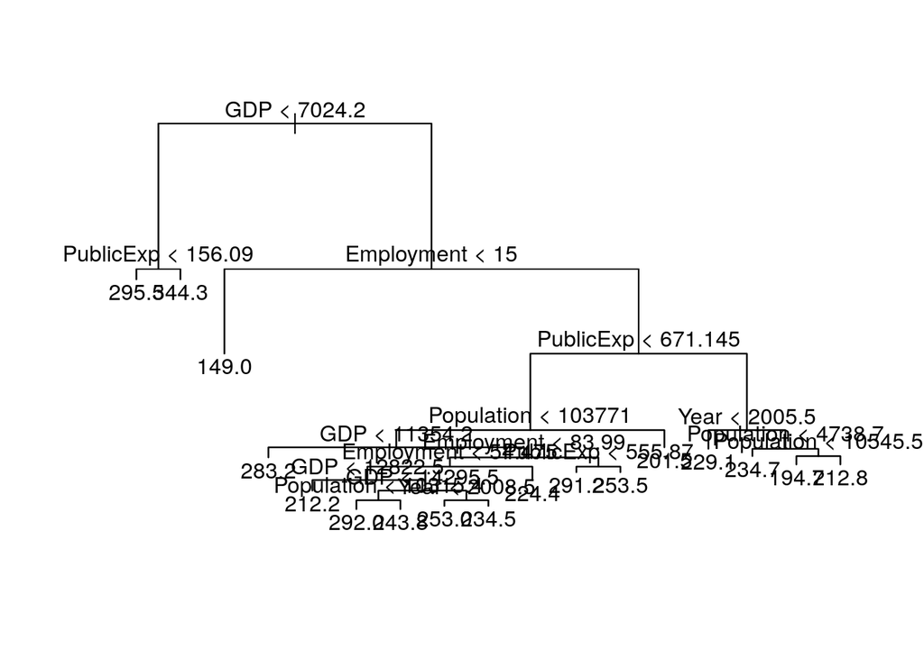

```r
plot(tree.Neo)
text(tree.Neo)
```

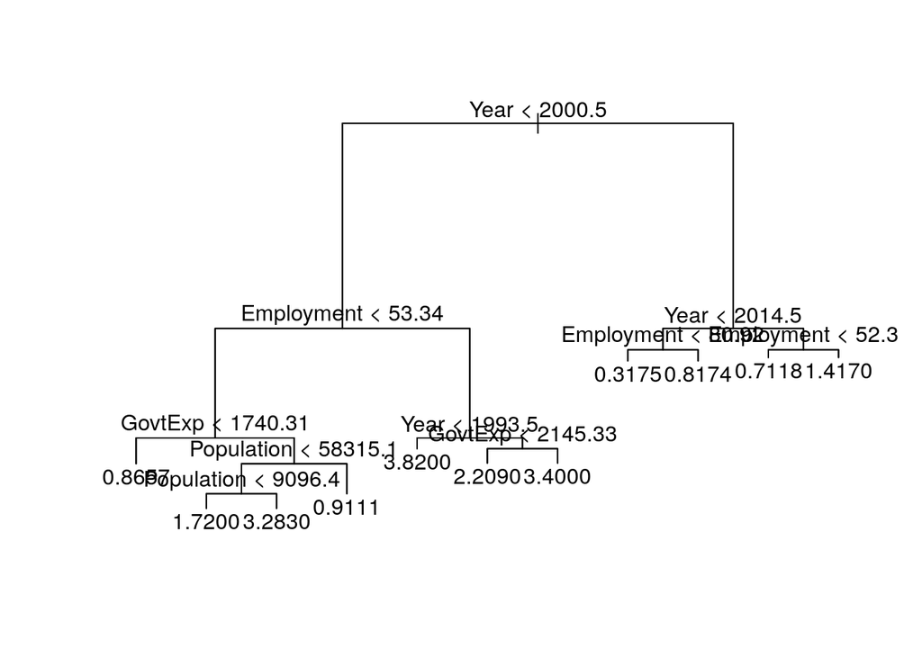

```r
plot(tree.Flu)
text(tree.Flu)
```

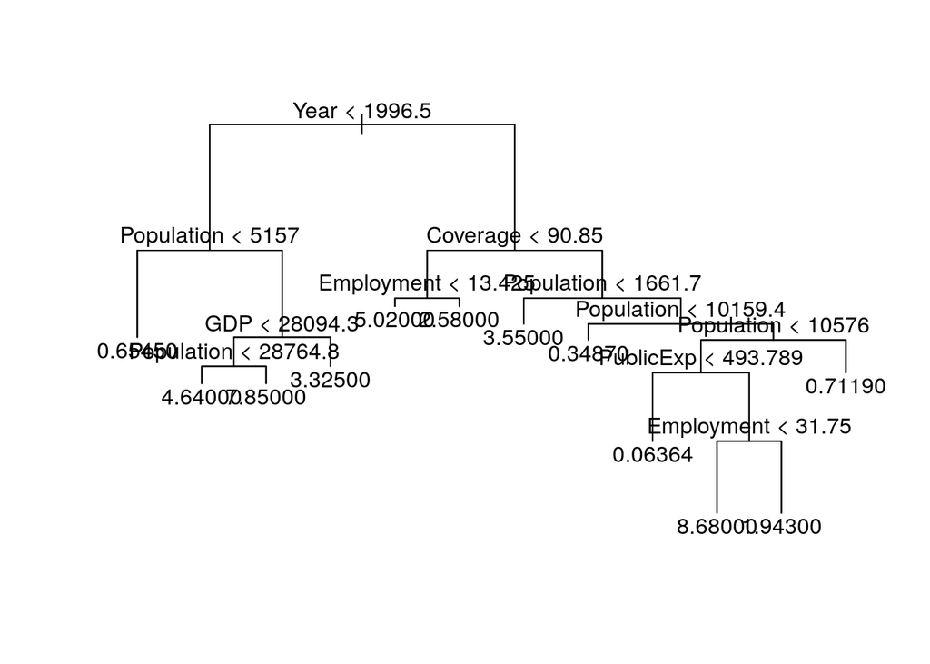

```r
plot(tree.HIV)
text(tree.HIV)
```

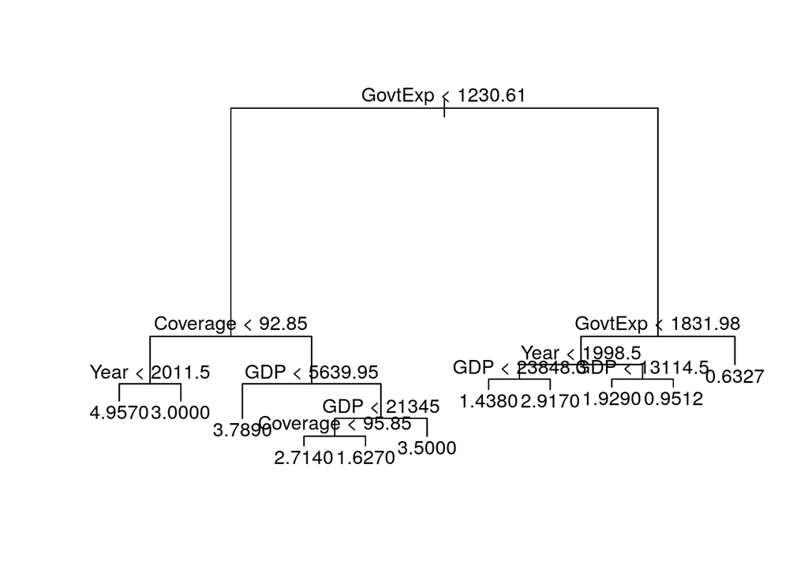

```r
plot(tree.Tub)
text(tree.Tub)
```

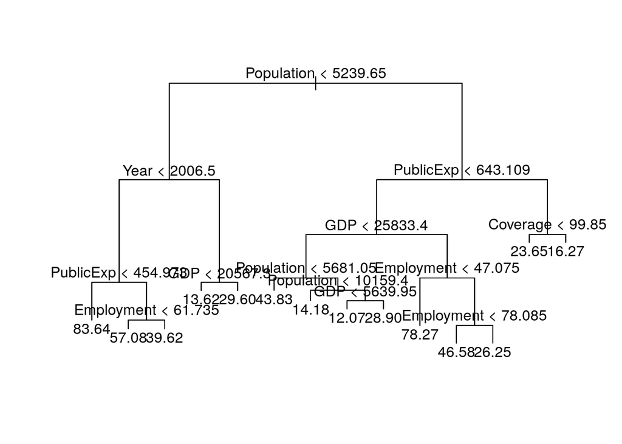

```r
plot(tree.Pne)
text(tree.Pne)
```